# Zadanie 4.5

A.Brodecka, M.Stolarczyk

18 kwietnia 2017

# 1 Podsumowanie

Na podstawie analizy wariancji możemy stwierdzić, że istnieją istotne różnice w proporcji poprawnie rozwiązanych zadań między studentami stosującymi różne strategie (punkt 3). W każdej dziedzinie pytań, najlepiej sobie radzą studenci, którzy szybko rozwiązują zadania na początku testu, a wolno na końcu testu. Najsłabsze wyniki osiągają osoby, które wolno rozwiązują zadania na początku testu, a szybko na końcu (punkt 4).

Na końcu dokumentu prezentujemy rankingi państw po względem poprawności rozwiązywania zadań, oczyszczone z wpływu stosowanej strategii rozwiązywania zadań (punkt 5).

# 2 Przygotowanie danych

Na podstawie danych z zadania 0 dla każdego studenta obliczamy frakcję poprawnie rozwiązanych zadań. Dodatkowo dołączamy kolumnę mówiącą o strategii stosowanej przez studenta.

| group | CNTRYID | CNTSTUID | result | W_FSTUWT | type_final |
| --- | --- | --- | --- | --- | --- |
| M | Australia | 3600001 | 0.7058824 | 32.00336 | 11 |
| M | Australia | 3600003 | 0.1875000 | 2.96411 | 01 |
| M | Australia | 3600004 | 0.3529412 | 28.20832 | 10 |
| M | Australia | 3600005 | 0.3076923 | 11.76316 | 10 |
| M | Australia | 3600009 | 0.8125000 | 26.45644 | 00 |
| M | Australia | 3600010 | 0.3750000 | 19.30947 | 10 |

# 3 Wpływ strategii na końcowy wynik

Aby sprawdzić, czy stosowana strategia wpływa na wyniki testów, stosujemy analizę wariancji. Sprawdzamy istotność strategii i państwa oraz interakcji tych dwóch czynników. Poniżej przedstawiamy wyniki testów.

## 3.1 Matematyka

```
##                        Df Sum Sq Mean Sq F value Pr(>F)
## type_final              3  20021    6674 3478.80 <2e-16 ***
## CNTRYID                57  68733    1206  628.58 <2e-16 ***
## type_final:CNTRYID    171   3321      19   10.12 <2e-16 ***
## Residuals          160182 307290       2
## ---
## Signif. codes:  0 '***' 0.001 '**' 0.01 '*' 0.05 '.' 0.1 ' ' 1
## 221 observations deleted due to missingness
```

## 3.2 Czytanie

```
##                        Df Sum Sq Mean Sq  F value Pr(>F)
## type_final              3  17354    5785 3086.759 <2e-16 ***
## CNTRYID                57  22457     394  210.232 <2e-16 ***
## type_final:CNTRYID    171   3152      18    9.835 <2e-16 ***
## Residuals          159763 299401       2
## ---
## Signif. codes:  0 '***' 0.001 '**' 0.01 '*' 0.05 '.' 0.1 ' ' 1
## 239 observations deleted due to missingness
```

## 3.3 Nauki przyrodnicze

```
##                        Df Sum Sq Mean Sq F value Pr(>F)
## type_final              3  40454   13485 7736.81 <2e-16 ***
## CNTRYID                57  93348    1638  939.61 <2e-16 ***
## type_final:CNTRYID    171   5103      30   17.12 <2e-16 ***
## Residuals          309479 539402       2
## ---
## Signif. codes:  0 '***' 0.001 '**' 0.01 '*' 0.05 '.' 0.1 ' ' 1
## 274 observations deleted due to missingness
```

## 3.4 Komentarz

Wszystkie powyższe testy odrzucają hipotezy zerowe na poziomie istotności 0.05. Zatem rodzaj stosowanej strategii, państwo oraz interakcje tych dwóch zmiennych mają wpływ na frakcję poprawnie rozwiązanych zadań.

# 4 Oszacowanie wpływu strategii na końcowy wynik

Aby oszacować wpływ strategii na wyniki testów, oczysczamy wyniki z wpływu państw, tj. odejmujemy od wyniku każdego studenta średni wynik w jego kraju i dodajemy średni wynik w całym badaniu. Następnie liczymy średnią z wyników w grupach wyznaczonych przez stosowaną strategię. Średnie są ważone przez zmienną `W_FSTUWT`.

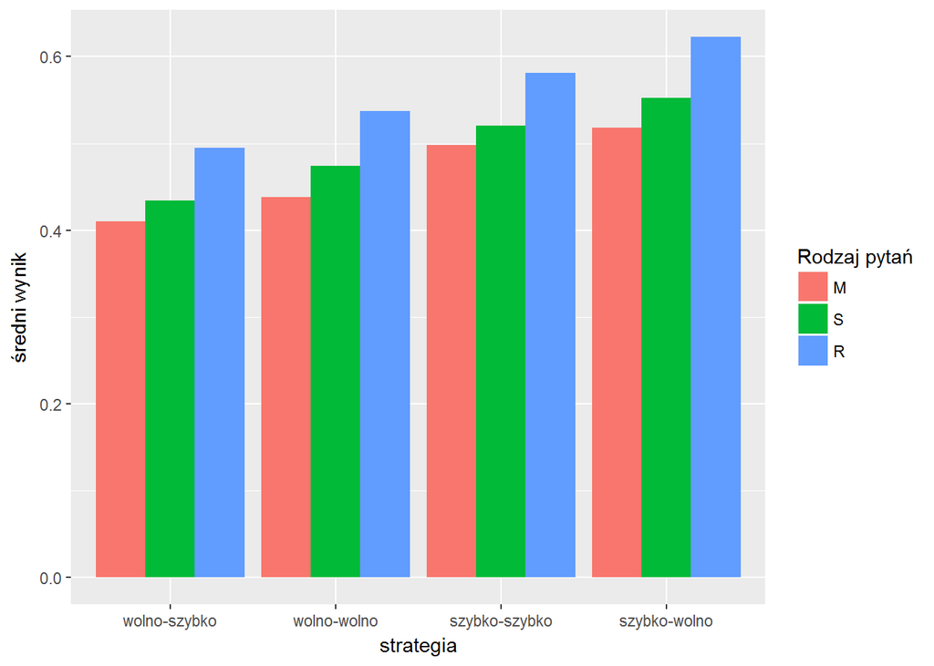

Możemy zaobserwować, że najlepsze wyniki osiągają osoby, które na początku szybko rozwiązują zadania, a później zwalniają. Najgorsze wyniki natomiast osiągają osoby, które wolno roziązują początkowe zadania, a szybko końcowe zadania. Osoby, które wszystkie zadania rozwiązują szybko albo wszystkie wolno osiągają pośrednie wyniki. Reguła ta jest taka sama w każdej grupie tematycznej pytań.

# 5 Ranking państw po usunięciu wpływu strategii

Aby usunąć wpływ strategii z rankingu państw od wyniku każdego studenta odejmujemy średnią wyników osób stosujących taką samą strategię i dodajemy średnią ogólną. Następnie liczymy średni wynik dla każdego państwa. Każdą średnią ważymy za pomocą zmiennej `W_FSTUWT`.

Poniżej prezentujemy tabelę z wynikami dla każdego państwa w każdej grupie tematycznej zadań.

|  | CNTRYID | Czytanie | Matematyka | Nauki przyrodnicze |
| --- | --- | --- | --- | --- |
| 1 | Australia | 0.579383414243552 | 0.513261614761816 | 0.544261228799658 |
| 2 | Austria | 0.588245828480511 | 0.52057511549542 | 0.536988301065682 |
| 3 | Belgium | 0.60939507306139 | 0.556119868874841 | 0.542008885585154 |
| 4 | Brazil | 0.486630391928255 | 0.33854237007596 | 0.385437056235952 |
| 5 | Bulgaria | 0.530224923426482 | 0.436742796289733 | 0.454654953362476 |
| 6 | Canada | 0.612615303790974 | 0.543591993743728 | 0.571992324268711 |
| 7 | Chile | 0.582629082950018 | 0.400317856054929 | 0.458227192491965 |
| 8 | Chinese Taipei | 0.588693965397009 | 0.583765205694832 | 0.580473036198056 |
| 9 | Colombia | 0.501081969401023 | 0.338066938210364 | 0.404495817172369 |
| 10 | Costa Rica | 0.522496547735756 | 0.352553452928889 | 0.399527572091833 |

[output cut: 48 more lines]

# 6 Kod

```r
library(dplyr)
library(stringi)
library(ggplot2)
library(DT)
library(tidyr)

dane <- readRDS("zadanie0_wynik.rds")
dane <- filter(dane, BOOKID >= 31 & BOOKID <= 61, !is.na(position))
klastry <- readRDS("klastry.rds")
dane %>% left_join(klastry, by="CNTSTUID") %>%
    filter(!is.na(type_final), type_final != "oth") ->
    dane2
```

```r
dane2 %>%
    mutate(group = stri_sub(item, 2, 2)) %>%
    mutate(result = 0 + (result == "Full credit")) %>%
    group_by(group, CNTRYID, CNTSTUID) %>%
    summarise(result = mean(result, na.rm = TRUE),
              W_FSTUWT = unique(W_FSTUWT),
              type_final = unique(type_final)) %>%
    ungroup() ->
    student_results

knitr::kable(head(student_results))
```

```r
student_results %>%
    filter(group == "M") %>%
    aov(result ~ type_final * CNTRYID, ., weights = W_FSTUWT) ->
    anova_math

summary(anova_math)
```

```r
student_results %>%
    filter(group == "R") %>%
    aov(result ~ type_final * CNTRYID, ., weights = W_FSTUWT) ->
    anova_read

summary(anova_read)
```

```r
student_results %>%
    filter(group == "S") %>%
    aov(result ~ type_final * CNTRYID, ., weights = W_FSTUWT) ->
    anova_sci

summary(anova_sci)
```

```r
student_results %>%
    mutate(type_final = ordered(type_final, levels=c("01", "11", "00", "10"),
                                labels=c("wolno-szybko", "wolno-wolno",
                                         "szybko-szybko", "szybko-wolno"))) %>%
    mutate(group = ordered(group, levels=c("M", "S", "R"))) %>%
    group_by(group, CNTRYID) %>%
    mutate(result_cleaned = result - weighted.mean(result, W_FSTUWT, na.rm = TRUE)) %>%
    group_by(group) %>%
    mutate(result_cleaned = result_cleaned + weighted.mean(result, W_FSTUWT, na.rm = TRUE)) %>%
    group_by(group, type_final) %>%
    summarise(result_cleaned = weighted.mean(result_cleaned, W_FSTUWT, na.rm = TRUE)) %>%
    ggplot(aes(x=type_final, y = result_cleaned, group = group, fill = group)) +
    geom_bar(stat="identity", position=position_dodge()) +
    xlab("strategia") +
    ylab("średni wynik") +
    scale_fill_discrete(name = "Rodzaj pytań")
```

```r
student_results %>%
    group_by(group, type_final) %>%
    mutate(result_cleaned = result - weighted.mean(result, W_FSTUWT, na.rm = TRUE)) %>%
    group_by(group) %>%
    mutate(result_cleaned = result_cleaned + weighted.mean(result, W_FSTUWT, na.rm = TRUE)) %>%
    group_by(group, CNTRYID) %>%
    summarise(result_cleaned = weighted.mean(result_cleaned, W_FSTUWT, na.rm = TRUE)) %>%
    ungroup() ->
    ranking

ranking %>%
    mutate(group = c("M"="Matematyka",
                     "R"="Czytanie",
                     "S"="Nauki przyrodnicze")[as.character(group)]) %>%
    spread(group, result_cleaned) %>%
    datatable()
```